# Lab 6: Introducing Classification

Objectives:

- To gain hands-on experience classifying small dataset
- To implement concepts related to Decision Tree classifier (i.e. Entropy, Information Gain), along with using existing libraries.

```python
# Run this cell if you use Colab
# from google.colab import drive
# drive.mount('/content/drive')
```

### Code it yourself

```python
import pandas as pd

# Read the data
df = pd.read_csv('toy_data.csv')
df
```

|  | age | income | student | credit rating | buys computer |
| --- | --- | --- | --- | --- | --- |
| 0 | <=30 | high | no | fair | no |
| 1 | <=30 | high | no | excellent | no |
| 2 | 31-40 | high | no | fair | yes |
| 3 | >40 | medium | no | fair | yes |
| 4 | >40 | low | yes | fair | yes |
| 5 | >40 | low | yes | excellent | no |
| 6 | 31-40 | low | yes | excellent | yes |
| 7 | <=30 | medium | no | fair | no |
| 8 | <=30 | low | yes | fair | yes |
| 9 | >40 | medium | yes | fair | yes |
| 10 | <=30 | medium | yes | excellent | yes |
| 11 | 31-40 | medium | no | excellent | yes |
| 12 | 31-40 | high | yes | fair | yes |
| 13 | >40 | medium | no | excellent | no |

```python
print(df.info())
```

```
<class 'pandas.DataFrame'>
RangeIndex: 14 entries, 0 to 13
Data columns (total 5 columns):
 #   Column         Non-Null Count  Dtype
---  ------         --------------  -----
 0   age            14 non-null     str
 1   income         14 non-null     str
 2   student        14 non-null     str
 3   credit rating  14 non-null     str
 4   buys computer  14 non-null     str
dtypes: str(5)
memory usage: 692.0 bytes
None
```

**TODO:** Write functions to compute Gain and Entropy, as discussed in the lecture.

```python
import numpy as np
```

```python
for i in df.columns[:3]:
    print(i)
    newdf = df.groupby(i)['buys computer'].value_counts().unstack()
    newdf['n'] = newdf['no'] +newdf['yes']
    newdf['pyes'] = newdf['yes']/newdf['n']
    newdf['pno'] = newdf['no']/newdf['n']

    newdf['Entropy'] = (-newdf['pyes'] * np.log2(newdf['pyes'])) - (newdf['pno'] * np.log2(newdf['pno']))
    newdf['sum'] = (newdf['n']/df.value_counts().count()) * newdf['Entropy']
    ans = 0.940 - newdf['sum'].sum()
    print(ans)
```

```
age
0.24646386110380814
income
0.028936606988323677
student
0.1515495426917104
```

```python
# Write your code here
def find_grain(df) :
    results = []
    newdf = df.groupby('buys computer').size()
    pyesT = newdf['yes']/newdf.sum()
    pnoT = newdf['no']/newdf.sum()
    mainEntropy = (-pyesT * np.log2(pyesT)) - (pnoT  * np.log2(pnoT))
    list = df.columns.drop('buys computer')
    for col in list :
        newdf = df.groupby(col)['buys computer'].value_counts().unstack()
        newdf['n'] = newdf['no'] +newdf['yes']
        newdf['pyes'] = newdf['yes']/newdf['n']
        newdf['pno'] = newdf['no']/newdf['n']
        newdf['Entropy'] = (-newdf['pyes'] * np.log2(newdf['pyes'])) - (newdf['pno'] * np.log2(newdf['pno']))
        newdf['sum'] = (newdf['n']/df.value_counts().count()) * newdf['Entropy']
        gain = mainEntropy - newdf['sum'].sum()
        results.append({'Attribute': col, 'Gain': gain})
    return pd.DataFrame(results)
```

```python
find_grain(df)
```

|  | Attribute | Gain |
| --- | --- | --- |
| 0 | age | 0.246750 |
| 1 | income | 0.029223 |
| 2 | student | 0.151836 |
| 3 | credit rating | 0.048127 |

### Using Libraries

Now that you know how to compute these values by yourselfs, now let's use some libraries.

**Steps:**

- Split the Data → Divide dataset into training (80%) and testing (20%).
- Train the Model → Fit a Decision Tree using the training data.
- Test the Model → Use the trained model to predict on test data.
- Evaluate Performance → Compare predictions with actual values (e.g., Accuracy Score).

Prepare features and labels.

```python
# Features
features = df.drop('buys computer', axis=1)
features

# Alternatively, you can use this:
# features = df.iloc[:, :-1]
```

|  | age | income | student | credit rating |
| --- | --- | --- | --- | --- |
| 0 | <=30 | high | no | fair |
| 1 | <=30 | high | no | excellent |
| 2 | 31-40 | high | no | fair |
| 3 | >40 | medium | no | fair |
| 4 | >40 | low | yes | fair |
| 5 | >40 | low | yes | excellent |
| 6 | 31-40 | low | yes | excellent |
| 7 | <=30 | medium | no | fair |
| 8 | <=30 | low | yes | fair |
| 9 | >40 | medium | yes | fair |
| 10 | <=30 | medium | yes | excellent |
| 11 | 31-40 | medium | no | excellent |
| 12 | 31-40 | high | yes | fair |
| 13 | >40 | medium | no | excellent |

```python
# Labels (or Target)
labels = df['buys computer']
labels

# # Alternatively, you can use this:
# labels = df.iloc[:, [-1]]
```

```
0      no
1      no
2     yes
3     yes
4     yes
5      no
6     yes
7      no
8     yes
9     yes
10    yes
11    yes
12    yes
13     no
Name: buys computer, dtype: str
```

```python
import pandas as pd
import matplotlib.pyplot as plt
from sklearn.model_selection import train_test_split
from sklearn.tree import DecisionTreeClassifier, plot_tree

# 1. Load the dataset
X = features.values  # Features
y = labels.values  # Target labels

# 2. Split the dataset into training (80%) and testing (20%)
X_train, X_test, y_train, y_test = train_test_split(X, y, test_size=0.2, random_state=42)

# 3. Create and train a Decision Tree model with entropy criterion
clf = DecisionTreeClassifier(criterion='entropy', max_depth=3, random_state=42)
clf.fit(X_train, y_train)
```

[output not shown]

[output cut: 15 more lines]

[output not shown]

There's an error:

**ValueError: could not convert string to float: '31-40'**

```python
from sklearn.preprocessing import LabelEncoder

# Initialize LabelEncoder
label_encoder = LabelEncoder()

# Apply Label Encoding for all categorical columns
df['age'] = label_encoder.fit_transform(df['age'])
df['income'] = label_encoder.fit_transform(df['income'])
df['student'] = label_encoder.fit_transform(df['student'])
df['credit rating'] = label_encoder.fit_transform(df['credit rating'])
df['buys computer'] = label_encoder.fit_transform(df['buys computer'])

# Display the encoded DataFrame
print(df)
```

```
    age  income  student  credit rating  buys computer
0     1       0        0              1              0
1     1       0        0              0              0
2     0       0        0              1              1
3     2       2        0              1              1
4     2       1        1              1              1
5     2       1        1              0              0
6     0       1        1              0              1
7     1       2        0              1              0
8     1       1        1              1              1
9     2       2        1              1              1
10    1       2        1              0              1
11    0       2        0              0              1
12    0       0        1              1              1
13    2       2        0              0              0
```

Let's check out an updated dataframe.

```python
df
```

|  | age | income | student | credit rating | buys computer |
| --- | --- | --- | --- | --- | --- |
| 0 | 1 | 0 | 0 | 1 | 0 |
| 1 | 1 | 0 | 0 | 0 | 0 |
| 2 | 0 | 0 | 0 | 1 | 1 |
| 3 | 2 | 2 | 0 | 1 | 1 |
| 4 | 2 | 1 | 1 | 1 | 1 |
| 5 | 2 | 1 | 1 | 0 | 0 |
| 6 | 0 | 1 | 1 | 0 | 1 |
| 7 | 1 | 2 | 0 | 1 | 0 |
| 8 | 1 | 1 | 1 | 1 | 1 |
| 9 | 2 | 2 | 1 | 1 | 1 |
| 10 | 1 | 2 | 1 | 0 | 1 |
| 11 | 0 | 2 | 0 | 0 | 1 |
| 12 | 0 | 0 | 1 | 1 | 1 |
| 13 | 2 | 2 | 0 | 0 | 0 |

```python
X = df.drop('buys computer', axis=1)  # Features
y = df['buys computer']  # Target
```

Let's continue where we left off!

```python
# 2. Split the dataset into training (80%) and testing (20%)
X_train, X_test, y_train, y_test = train_test_split(X, y, test_size=0.2, random_state=42)

# 3. Create and train a Decision Tree model with entropy criterion
clf = DecisionTreeClassifier(criterion='entropy', max_depth=3, random_state=42)
clf.fit(X_train, y_train)
```

```
DecisionTreeClassifier(criterion='entropy', max_depth=3, random_state=42)
```

```python
print(X_train.shape)
print(X_test.shape)
```

```
(11, 4)
(3, 4)
```

Now we're going build the Decision Tree Classifier

```python
from sklearn.tree import DecisionTreeClassifier

# Initialize the Decision Tree classifier
clf = DecisionTreeClassifier(criterion='entropy', random_state=42)  # Using 'entropy' as the criterion

# Train the model
clf.fit(X_train, y_train)

# Predict on the test set
y_pred = clf.predict(X_test)
```

And evaluate our model.

```python
from sklearn.metrics import accuracy_score, classification_report, confusion_matrix

# Calculate accuracy
accuracy = accuracy_score(y_test, y_pred)
print(f"Accuracy: {accuracy:.2f}")

# Classification report
print("Classification Report:")
print(classification_report(y_test, y_pred))

# Confusion Matrix
print("Confusion Matrix:")
print(confusion_matrix(y_test, y_pred))
```

```
Accuracy: 1.00
Classification Report:
              precision    recall  f1-score   support

           0       1.00      1.00      1.00         1
           1       1.00      1.00      1.00         2

    accuracy                           1.00         3
   macro avg       1.00      1.00      1.00         3
weighted avg       1.00      1.00      1.00         3

Confusion Matrix:
[[1 0]
 [0 2]]
```

And visualize our tree!

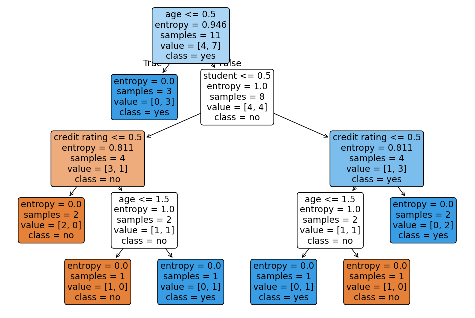

```python
import matplotlib.pyplot as plt
from sklearn.tree import plot_tree

# Plot the decision tree
plt.figure(figsize=(12, 8))
plot_tree(clf, filled=True, feature_names=X.columns, class_names=['no', 'yes'], rounded=True)
plt.show()
```

Put them all together.

```
Accuracy: 1.00
Classification Report:
              precision    recall  f1-score   support

           0       1.00      1.00      1.00         1
           1       1.00      1.00      1.00         2

    accuracy                           1.00         3
   macro avg       1.00      1.00      1.00         3
weighted avg       1.00      1.00      1.00         3

Confusion Matrix:
[[1 0]
 [0 2]]
```

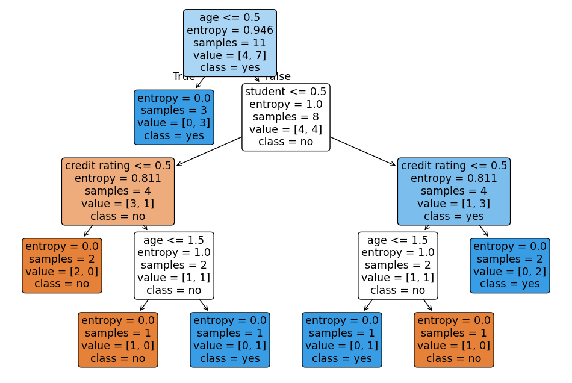

```python
import pandas as pd
from sklearn.preprocessing import LabelEncoder
from sklearn.model_selection import train_test_split
from sklearn.tree import DecisionTreeClassifier
from sklearn.metrics import accuracy_score, classification_report, confusion_matrix
import matplotlib.pyplot as plt
from sklearn.tree import plot_tree

# data
data = pd.read_csv('toy_data.csv')

df = pd.DataFrame(data)

# Encode categorical columns using LabelEncoder
label_encoder = LabelEncoder()
df['age'] = label_encoder.fit_transform(df['age'])
df['income'] = label_encoder.fit_transform(df['income'])
df['student'] = label_encoder.fit_transform(df['student'])
df['credit rating'] = label_encoder.fit_transform(df['credit rating'])
df['buys computer'] = label_encoder.fit_transform(df['buys computer'])

# Separate features (X) and target (y)
X = df.drop('buys computer', axis=1)
y = df['buys computer']

# Split the dataset into training and test sets (80% train, 20% test)
X_train, X_test, y_train, y_test = train_test_split(X, y, test_size=0.2, random_state=42)

# Initialize the Decision Tree classifier
clf = DecisionTreeClassifier(criterion='entropy', random_state=42)

# Train the model
clf.fit(X_train, y_train)

# Predict on the test set
y_pred = clf.predict(X_test)

# Calculate accuracy
accuracy = accuracy_score(y_test, y_pred)
print(f"Accuracy: {accuracy:.2f}")

# Classification report
print("Classification Report:")
print(classification_report(y_test, y_pred))

# Confusion Matrix
print("Confusion Matrix:")
print(confusion_matrix(y_test, y_pred))

# Plot the decision tree
plt.figure(figsize=(12, 8))
plot_tree(clf, filled=True, feature_names=X.columns, class_names=['no', 'yes'], rounded=True)
plt.show()
```

Is the output tree the same as what you calculated yourself? Explain in your own words why they are the same or different.

Another example, another dataset -- Iris

```
Model Accuracy: 1.00
```

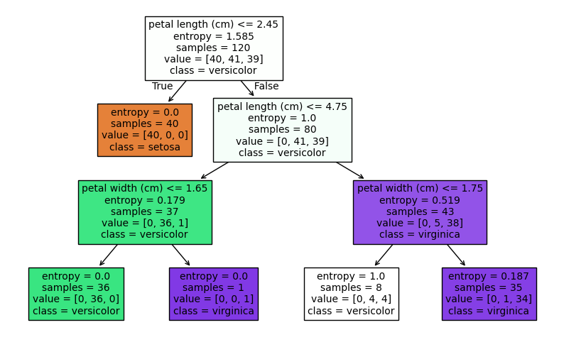

```python
from sklearn.datasets import load_iris

# 1. Load the Iris dataset
iris = load_iris()
X = iris.data  # Features
y = iris.target  # Target labels

# 2. Split the dataset into training (80%) and testing (20%)
X_train, X_test, y_train, y_test = train_test_split(X, y, test_size=0.2, random_state=42)

# 3. Create and train a Decision Tree model with entropy criterion
clf = DecisionTreeClassifier(criterion='entropy', max_depth=3, random_state=42)
clf.fit(X_train, y_train)

# 4. Make predictions on the test set
y_pred = clf.predict(X_test)

# 5. Evaluate the model
accuracy = accuracy_score(y_test, y_pred)
print(f"Model Accuracy: {accuracy:.2f}")

# 6. Visualize the Decision Tree
plt.figure(figsize=(10, 6))
plot_tree(clf, filled=True, feature_names=iris.feature_names, class_names=iris.target_names)
plt.show()
```